# DATA2002 Report Assignment

SID 500666580

19/09/2021

# 1 Introduction

First, as this survey only considered students taking a particular course at the University of Sydney, the sample students are not randomly selected nor representative of the whole group of Australian students, an entire population.  
Likewise, the level of stress students feel was quantified as self-assessed stress scale data on a scale from 0 representing the smallest amount of stress to 10 representing the largest amount of stress. One potential bias with this stress data is that it is hard to quantify how much students are stressed with a single question. Furthermore, since these students are not professional mental health-related personnel, they may have measured their degrees of stress inaccurately.

On the other hand, non-responses and inconsistency of data have been detected across several survey questions. Although the amount of such invalid data that are related to this analysis is small, it requires further studies with larger-sized random sample data. Notably, this analysis has cleaned up data to deal with such issues related to inconsistent and missing data.  
Overall, even if this report provides readers with remarkable findings, further thorough research is required to validate our findings.

# 2 The Language of Statistics

Before investigating our analyses, it is worthwhile to know statistical notations and terminologies that will be frequently used to interpret our results below. The common language of statistics required for readers to know is the following:

> **1. Hypothesis tests**

> In general, hypothesis tests refer to statistical tests that are utilized to make statistical inferences by either rejecting a **null hypothesis** in favor of an **alternative hypothesis** or not rejecting the null hypothesis.  
> The **null hypothesis** is a statement about equalities (i.e., status-quo) between two different population parameters (the numerical facts about the entire population), and it is denoted by $H_0$. While an **alternative hypothesis** is a statement about inequalities and such inequalities could be “greater than”, “less than”, or “not equal to” between two different parameters used in $H_0$. The alternative hypothesis is denoted by $H_1$ or $H_a$.

> In a hypothesis test, we first assume $H_0$ is true. Then under $H_0$, we compute a single statistic called a **test statistic** from our observed data. Such an observed test statistic, $t_0$ is utilized as a *rejection criterion* given a particular significance level $\alpha$. The significance level $\alpha$, which is also known as a false alarm rate, measures the probability that we incorrectly reject true $H_0$, and hence we want it to be small. The most commonly used value of $\alpha$ is 0.05 and the significance level of 0.05 will also be used in this report.

> Lastly, we compute a p-value to decide whether we reject $H_0$ or not. p-values are computed in different ways depending on the statement of $H_1$ and types of hypothesis tests. For instance, in a general hypothesis test, if $H_1: \mu > \mu_0$, where $\mu$ is a true population mean of a certain status, while $\mu_0$ is a null hypothesized mean, the p-value is calculated as the proportion of test statistics $T$ that are as ore more extreme than our observed test statistic $t_0$, under $H_0$ (i.e., $P\left(T\ge t_0\right)$). In such a case, we reject $H_0$ if and only if $P\left(T\ge t_0\right)$ is less than a pre-specified $\alpha$, and we do not reject $H_0$, otherwise.

> **2. Confidence intervals**

> Another way of making statistical inferences is to use a confidence interval. Confidence intervals are intervals that are likely to capture a true population parameter at a certain percentage of level $c$. The value of $c$ is called **critical value** and is determined by the significance level $\alpha$. For example, if $\alpha=0.05$, we use $c=0.95$ and construct a 95% confidence interval.

More specific terminologies will be introduced in section 3 Results / Analysis.

# 3 Resulsts / Analysis

## 3.1 Data Cleaning

```r
# load necessary libraries
library(tidyverse)
library(janitor)
library(visdat)
library(cowplot)
library(naniar)
library(gendercoder)
library(grid)
library(gridExtra)

# Data Cleaning
data_path = "/Users/sanghyunkim/Desktop/Data Science Project/Other Analysis/University Projects/DATA2002-report-assignment/data/DATA2x02 survey (Responses) - Form responses 1.csv"
survey = readr::read_csv(data_path)

# 1. rename column names
short_colnames = c("time","covid_tests","living_arrangements","height",
                "wednesday","in_aus","math_ability","r_ability",
                "data2002","year","webcam","vaccination","social_media",
                "gender","steak_preference","dominant_hand","stress",
                "lonely","emails","sign_off","salary","unit","major","exercise")
colnames(survey) = short_colnames

# 2. 'height' data cleaning
## keep data consistency of 'height' column
survey = survey %>%
  dplyr::mutate(height = readr::parse_number(height),
                height = case_when(
                  height <= 2.5 ~ height * 100,
                  height <= 9 ~ NA_real_,
                  TRUE ~ height
                ))

# 3. 'wednesday' data cleaning
## remove any punctuation in the 'wednesday' column'
survey = survey %>% mutate(wednesday = stringr::str_replace_all(wednesday, "[[::pucnt::]]", ""),
                           wednesday = stringr::str_to_title(wednesday),
                           wednesday = fct_lump_n(wednesday, n = 2))

## check the new and clean 'wednesday' data
janitor::tabyl(survey, wednesday)

# 4. 'year' data cleaning
survey = survey %>%
  mutate(year = case_when(
   stringr::str_detect(tolower(year), "first") ~ "first-year",
   stringr::str_detect(tolower(year), "second") ~ "second-year",
   stringr::str_detect(tolower(year), "third") ~ "third-year",
   TRUE ~ NA_character_
  ))

## check the new and clean 'year' data
janitor::tabyl(survey, year)

# 5. 'gender' data cleaning
survey = survey %>%
  mutate(
    gender = case_when(
      gender == "Woman/Female" ~ "female",
      TRUE ~ gender),
    gender = gendercoder::recode_gender(gender)
    )

## check the new and clean 'gender' data
janitor::tabyl(survey, gender)

# 6. 'living_arrangements' data cleaning
survey = survey %>% mutate(
  living_arrangements = fct_lump_n(living_arrangements, n = 5)
)
## check the new and clean 'living_arrangements' data
janitor::tabyl(survey, living_arrangements)

# 7. 'salary' data cleaning
survey = survey %>% mutate(salary = tolower(gsub("[.,$/? ]", "", salary)),
                           salary = case_when(
                             stringr::str_detect(salary, "^[a-z]") ~ NA_real_,
                             stringr::str_detect(salary,"-") ~ NA_real_,
                             stringr::str_detect(salary, "k") ~ as.numeric(parse_number(salary)) * 1000,
                             stringr::str_detect(salary, "week") ~ as.numeric(parse_number(salary)) * 52,
                             stringr::str_detect(salary, "pw") ~ as.numeric(parse_number(salary)) * 52,
                             stringr::str_detect(salary, "month") ~ as.numeric(parse_number(salary)) * 12,
                             stringr::str_detect(salary, "pm") ~ as.numeric(parse_number(salary)) * 12,
                             stringr::str_detect(salary, "pa") ~ as.numeric(parse_number(salary)),
                             stringr::str_detect(salary, "year") ~ as.numeric(parse_number(salary)),
                             stringr::str_detect(salary, "aud") ~ as.numeric(parse_number(salary)),
                             stringr::str_detect(salary, "[[:alpha:]]") ~ NA_real_,
                             TRUE ~ as.numeric(salary)
                           ))
survey = survey %>%
  mutate(salary = case_when(
    salary <= 20000 ~ NA_real_,
    TRUE ~ salary
  ))

survey = survey %>% mutate(major = stringr::str_replace(major, "science", "Science"),
                           major = stringr::str_replace(major, "physics", "Physics"),
                           major = stringr::str_replace(major, "Analyst", "Analytics"),
                           major = stringr::str_replace(major, "analytics", "Analytics"),
                           major = stringr::str_replace(major, " \\s*\\([^\\)]+\\)", ""),
                           major = case_when(
                             stringr::str_detect(major, "an elective") ~ "Elective",
                             TRUE ~ major))
janitor::tabyl(survey, major)
```

## 3.2 COVID-19 Tests Distribution Analysis

In statistics, knowing how well our sample data fit one of the well-known statistical distributions (e.g., Poisson distributions) enables us to model data, and thereby, have a reasonable expectation about what we are likely to find in the entire population.  
A chi-squared goodness-of-fit test is one type of hypothesis test where statisticians measure how well our observed data fit any given discrete distribution where the number of outcomes is discrete (i.e., integer-valued data distribution). Therefore, in this analysis, we will perform a chi-squared goodness-of-fit test where $H_0$ claims that the observed counts of the number of times students have taken COVID-19 tests follow a Poisson distribution, while $H_1$ states that they do not.

Before conducting a chi-squared goodness-of-fit test, we excluded missing data to derive a meaningful result. As shown in Graph 3.2.1 below, there were initially 1.4% of missing data. Since we do not know whether these missing values represent 0 times or any other possible number of times students have taken COVID-19 tests, we will exclude those missing data. Graph 3.2.2 shows an approximate distribution of our observed sample data. As this histogram provides insufficient information about its underlying distribution, we tabulated expected counts for each corresponding number of times students have taken COVID-19 tests. (Table 3.2.1)

At this stage, it is noteworthy to check a significant assumption for chi-squared tests. Chi-squared tests work if and only if the expected frequencies are greater than or equal to 5, and the observations must be independent of each other. According to Table 3.2.1, although the observed frequencies for the corresponding number of times COVID-19 tests taken by students are independent of one another, the expected frequencies are less than 5 for some groups.  
Thus, we combine some of those groups to satisfy the chi-squared test assumption, and the result was tabulated in Table 3.2.2. Since the combined expected count is 4.3 for students who have taken COVID-19 tests four or more times, we classify the original data into four different groups as shown in Table 3.2.2.

With this final observed counts data, we perform a chi-squared goodness-of-test, and the result is shown in Table 3.2.3. The observed test statistic is calculated from the observed data, and degrees of freedom ($df$) is determined by a formula:
$$df=k-1-q$$
where $k$ and $q$ represent the number of groups and the number of estimated parameters, respectively. As we have estimated a parameter $\lambda$ to compute Poisson distribution probabilities for each of those 4 groups, we subtract one degree of freedom, and therefore, the resulting degrees of freedom is $4-1-1=2$.
The approximate p-value of 0 tells us the proportion of test statistics $T$ that are as or more extreme than the observed test statistics (70.91) is roughly 0, indicating that we reject $H_0$ at a significance level $\alpha=0.05$. Such a result also matches Graph 3.2.3 that depicts a clear difference between observed and expected frequencies for each group.

Hence, we can conclude that the observed data does not follow a Poisson distribution. Nonetheless, as mentioned earlier, further studies are required with a larger-sized random sample data because our data is not randomly selected, and hence, is not representative of the entire population, the whole group of Australian students.

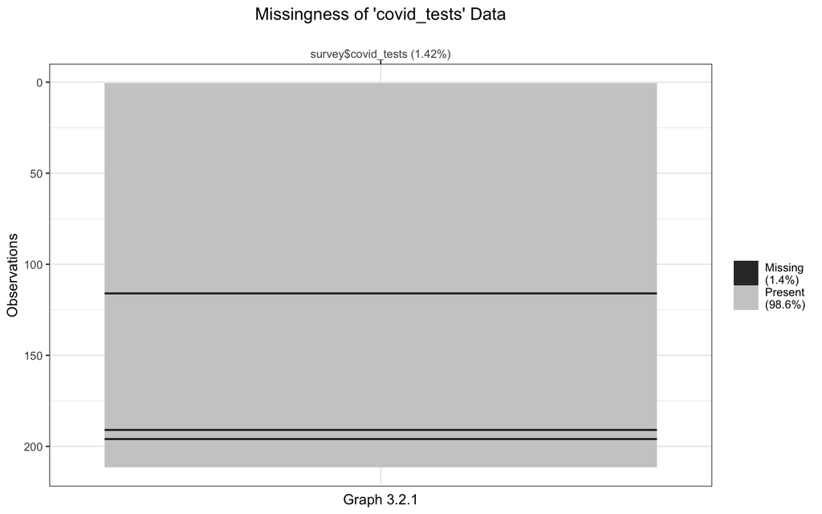

```r
# explore missing data
covid_tests_df = tibble(survey$covid_tests)
vis_miss(covid_tests_df) +
  labs(title = "Missingness of 'covid_tests' Data",
       caption = "Graph 3.2.1") +
  theme_bw(base_size = 10) +
  theme(plot.title = element_text(hjust = 0.5),
        plot.caption = element_text(hjust = 0.5, size = 10))
```

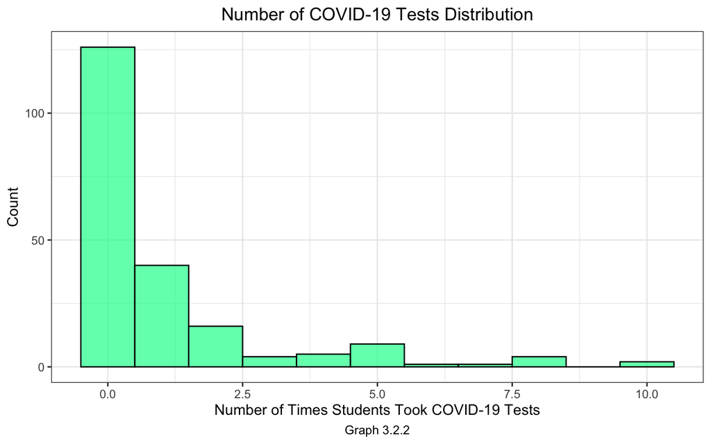

```r
# exclude missing 'covid_tests' data
covid_tests = survey %>%
  filter(!is.na(covid_tests)) %>%
  select(covid_tests)

# visualize the number of times that students have taken COVID tests (without missing data)
covid_tests %>% ggplot() +
  aes(x = covid_tests) +
  geom_histogram(binwidth = 1, color = "black", fill = "mediumspringgreen", alpha = 0.7) +
  labs(x = "Number of Times Students Took COVID-19 Tests",
       y = "Count", title = "Number of COVID-19 Tests Distribution",
       caption = "Graph 3.2.2") +
  theme_bw(base_size = 12) +
  theme(plot.title = element_text(hjust = 0.5),
        plot.caption = element_text(hjust = 0.5, size = 10))
```

```r
# explore 'covid_tests' data without missing data
covid_tests = survey %>%
  group_by(covid_tests) %>%
  select(covid_tests) %>%
  count()

# vectorize 'covid_tests' data
y = covid_tests$n # number of observations for corresponding number of times students have taken COVID tests
x = covid_tests$covid_tests # unique number of times students have taken COVID tests

# since none of the students have taken COVID tests 9 times,
# add 0 to y, and 9 to x
y = c(y[1:9], 0, y[10])
x = c(x[1:9], 9, x[10])

## statistics required for a chi-squared test
n = sum(y) # total number of observations
k = length(y) # number of groups
estimated_lam = sum(y * x)/n # estimate lambda
p = dpois(x, estimated_lam) # obtain probabilities for each x value from Poisson pmf

# round up probabilities (4 decimal places)
p = round(p, 4)
# the probabilities sum to 1
sum(p)
```

```
## [1] 1
```

```r
# compute expected counts
e = n * p

# check if all the expected counts are greater than or equal to 5 - a chi-squared test assumption
expected_counts_df = tibble(
  COVID_Tests = x,
  Expected_Counts = e)
knitr::kable(expected_counts_df, digits = 1, caption = "Table 3.2.1: Original Expected Counts")
```

Table 3.2.1: Original Expected Counts

| COVID_Tests | Expected_Counts |
| --- | --- |
| 0 | 74.3 |
| 1 | 76.5 |
| 2 | 39.4 |
| 3 | 13.5 |
| 4 | 3.5 |
| 5 | 0.7 |
| 6 | 0.1 |
| 7 | 0.0 |
| 8 | 0.0 |
| 9 | 0.0 |
| 10 | 0.0 |

```r
  # as some of the expected counts are not greater than or equal to 5,
# combine those expected counts (corresponding x = 3:10)
new_y = c(y[1:3], sum(y[4:11]))
new_p = c(p[1:3], sum(p[4:11]))
new_e = c(e[1:3], sum(e[4:11]))
new_k = length(new_y)
new_x = c("0", "1", "2", "3+")

# statistics required for a chi-squared test (a summary)
stats = tibble(
  COVID_Tests = new_x,
  Observed_Counts = new_y,
  Probabilities = new_p,
  Expected_Counts = round(new_e, 1),
)
knitr::kable(stats, caption = "Table 3.2.2: Final Statistics for a Chi-squared goodness-of-fit Test")
```

Table 3.2.2: Final Statistics for a Chi-squared goodness-of-fit Test

| COVID_Tests | Observed_Counts | Probabilities | Expected_Counts |
| --- | --- | --- | --- |
| 0 | 126 | 0.3574 | 74.3 |
| 1 | 40 | 0.3677 | 76.5 |
| 2 | 16 | 0.1892 | 39.4 |
| 3+ | 26 | 0.0857 | 17.8 |

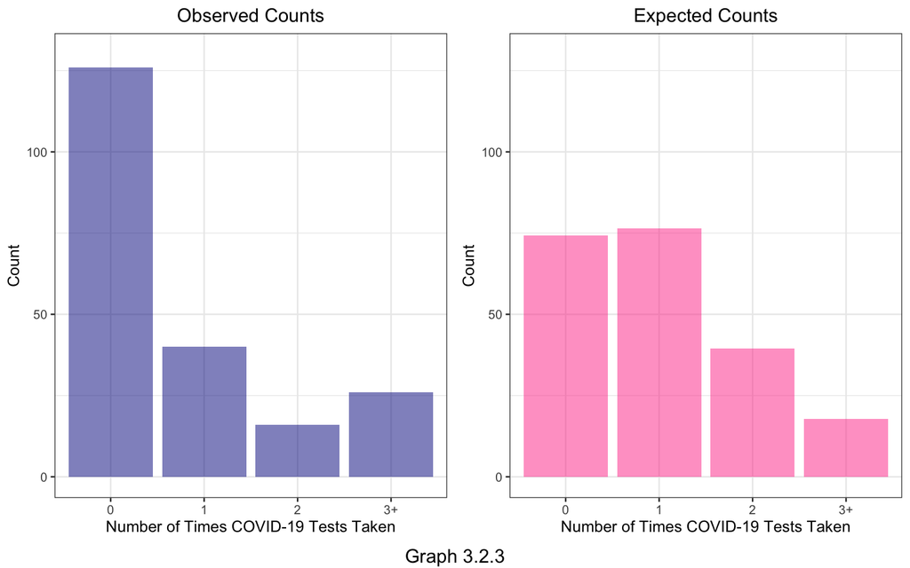

```r
# compare observed counts and expected counts
obs_counts = stats %>% ggplot() +
  aes(x = COVID_Tests, y = Observed_Counts) +
  geom_bar(stat = "identity", alpha = 0.5, fill = "darkblue") +
  labs(x = "Number of Times COVID-19 Tests Taken", y = "Count", title = "Observed Counts") +
  coord_cartesian(ylim = c(0, 130)) +
  theme_bw(base_size = 10) +
  theme(plot.title = element_text(hjust = 0.5))

exp_counts =stats %>% ggplot() +
  aes(x = COVID_Tests, y = Expected_Counts) +
  geom_bar(stat = "identity", alpha = 0.5, fill = "violetred1") +
  labs(x = "Number of Times COVID-19 Tests Taken", y = "Count", title = "Expected Counts") +
  coord_cartesian(ylim = c(0, 130)) +
  theme_bw(base_size = 10) +
  theme(plot.title = element_text(hjust = 0.5))

grid.arrange(obs_counts, exp_counts, nrow = 1,
             bottom = textGrob("Graph 3.2.3", hjust = 0.5))
```

```r
# compute the observed test statistic
t0 = sum((new_y - new_e)^2/new_e)

# compute a p-value (df = k - 1 - 1)
p_val = pchisq(t0, df = new_k - 1 - 1, lower.tail = FALSE)

# chi-squared goodness-of-fit test result
chisq.result = matrix(data = c(t0, new_k - 1 - 1, p_val),
                      ncol = 3, byrow = TRUE)
rownames(chisq.result) = "Value"
colnames(chisq.result) = c("Observed Test Statistic", "df", "p-value")
knitr::kable(chisq.result, caption = "Table 3.2.3: Chi-squared Goodness-of-fit Test Result")
```

Table 3.2.3: Chi-squared Goodness-of-fit Test Result

|  | Observed Test Statistic | df | p-value |
| --- | --- | --- | --- |
| Value | 70.90979 | 2 | 0 |